# Parastichopus parvimenesis - Migrate-n

This notebook will document a migrate-n analysis that I ran for *Parastichopus parvimensis*. I am working with Alison Haupt who received reviewer comments on a manuscript that urged her to do a migrate-n analysis.

First, the FASTA file taxon names are a bit funky, so I did some quick grepping in Textwrangler to distinguish taxon numbers from locality names:

Find: “_()$"  
Replace: “-\1”

Now taxon numbers are separated by a “-” while locality names can include “_"

## Read and check data

Read in the data and check alignment:

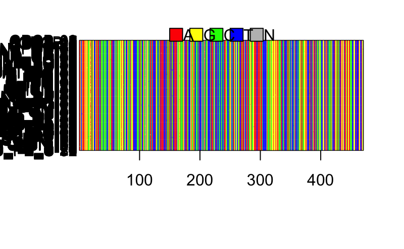

Pop off the population names, make a quick haplotype network. Looks pretty panmictic…

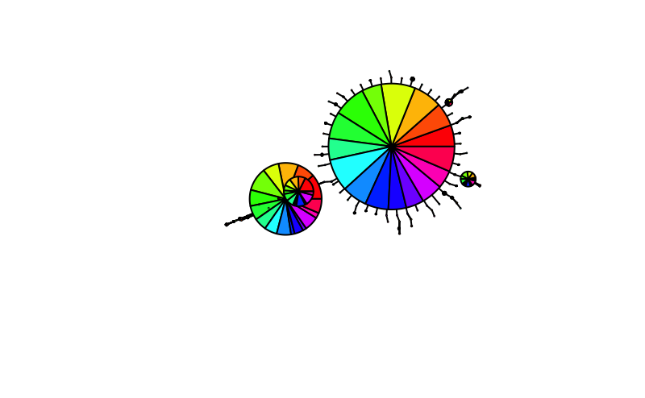

[figure not shown]

```r
pop<-gsub(names(ppar),pattern = "-\\d+",replacement="")
d <- dist.dna(ppar)
h <- pegas::haplotype(ppar)
h <- sort(h, what = "label")
net <- pegas::haploNet(h)
i<-stack(setNames(attr(h, "index"), rownames(h)))
i<-i[order(i$values),]
ind.hap<-table(hap=i$ind, pop=pop)
#play with scale.ratio to get appropriate branch lengths
plot(net,size=attr(net, "freq"), scale.ratio=10, pie=ind.hap,legend=F, labels=F,threshold=0, show.mutation=2)
plot.new()

legend("topleft", colnames(ind.hap), col=rainbow(ncol(ind.hap)), pch=19, ncol=2)
```

Wrote out the data as nexus format and edited it manually to migrate format.

## Run Modeltest

|  | Model | df | logLik | AIC | AICw | AICc | AICcw | BIC |
| --- | --- | --- | --- | --- | --- | --- | --- | --- |
| 6 | K80+G | 1217 | -1683.636 | 5801.273 | 1.704052e-02 | NaN | NaN | 10855.15 |
| 8 | HKY+G | 1220 | -1679.088 | 5798.176 | 8.014923e-02 | NaN | NaN | 10864.51 |
| 10 | SYM+G | 1221 | -1679.033 | 5800.067 | 3.114200e-02 | NaN | NaN | 10870.55 |
| 12 | GTR+G | 1224 | -1672.702 | 5793.403 | 8.716683e-01 | NaN | NaN | 10876.35 |
| 5 | K80 | 1216 | -1723.908 | 5879.816 | 1.499561e-19 | NaN | NaN | 10929.54 |
| 7 | HKY | 1219 | -1719.110 | 5876.219 | 9.058657e-19 | NaN | NaN | 10938.40 |
| 9 | SYM | 1220 | -1718.935 | 5877.871 | 3.967061e-19 | NaN | NaN | 10944.20 |
| 11 | GTR | 1223 | -1712.558 | 5871.117 | 1.161642e-17 | NaN | NaN | 10949.91 |
| 2 | JC+G | 1216 | -1775.030 | 5982.061 | 9.417061e-42 | NaN | NaN | 11031.78 |
| 4 | F81+G | 1219 | -1770.027 | 5978.055 | 6.978593e-41 | NaN | NaN | 11040.24 |

[output cut: 2 more lines]

```r
# some funky code to get the gamma shape parameter
env<-attr(ppar_modeltest, "env")
HKY<-get("HKY+G", env)
eval(HKY, env=env)
```

So the gamma distribution looks like this:

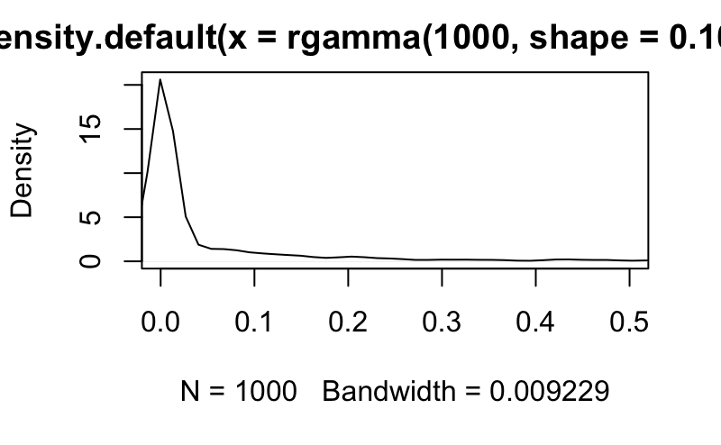

Using migrate-n to discretize that gamma into four categories we get:

rates=4: 0.333841 1.589418 3.974628 8.077175 prob-rates=4: 0.561404 0.391364 0.046548 0.000684

And the transition/transversion ratio is:

```r
TiTvRatio(ppar)
```

```
         Ti          Tv Ti.Tv.ratio
  79.000000   23.000000    3.434783
```

So we will use those numbers in our parmfiles

## Parmfile

### Migration Models

Symmetric gene flow 1. Panmixia

2. Island Model

m m m m m m m m m m m m m m m  
m m m m m m m m m m m m m m m  
m m m m m m m m m m m m m m m  
m m m m m m m m m m m m m m m  
m m m m m m m m m m m m m m m  
m m m m m m m m m m m m m m m  
m m m m m m m m m m m m m m m  
m m m m m m m m m m m m m m m  
m m m m m m m m m m m m m m m  
m m m m m m m m m m m m m m m  
m m m m m m m m m m m m m m m  
m m m m m m m m m m m m m m m  
m m m m m m m m m m m m m m m  
m m m m m m m m m m m m m m m  
m m m m m m m m m m m m m m m

3. Stepping-Stone

* s 0 0 0 0 0 0 0 0 0 0 0 0 0  
s * s 0 0 0 0 0 0 0 0 0 0 0 0  
0 s * s 0 0 0 0 0 0 0 0 0 0 0  
0 0 s * s 0 0 0 0 0 0 0 0 0 0  
0 0 0 s * s 0 0 0 0 0 0 0 0 0  
0 0 0 0 s * s 0 0 0 0 0 0 0 0  
0 0 0 0 0 s * s 0 0 0 0 0 0 0  
0 0 0 0 0 0 s * s 0 0 0 0 0 0  
0 0 0 0 0 0 0 s * s 0 0 0 0 0  
0 0 0 0 0 0 0 0 s * s 0 0 0 0  
0 0 0 0 0 0 0 0 0 s * s 0 0 0  
0 0 0 0 0 0 0 0 0 0 s * s 0 0  
0 0 0 0 0 0 0 0 0 0 0 s * s 0  
0 0 0 0 0 0 0 0 0 0 0 0 s * s  
0 0 0 0 0 0 0 0 0 0 0 0 0 s *

4. Stepping-stone -South dispersal

* 0 0 0 0 0 0 0 0 0 0 0 0 0 0  
* * 0 0 0 0 0 0 0 0 0 0 0 0 0  
0 * * 0 0 0 0 0 0 0 0 0 0 0 0  
0 0 * * 0 0 0 0 0 0 0 0 0 0 0  
0 0 0 * * 0 0 0 0 0 0 0 0 0 0  
0 0 0 0 * * 0 0 0 0 0 0 0 0 0  
0 0 0 0 0 * * 0 0 0 0 0 0 0 0  
0 0 0 0 0 0 * * 0 0 0 0 0 0 0  
0 0 0 0 0 0 0 * * 0 0 0 0 0 0  
0 0 0 0 0 0 0 0 * * 0 0 0 0 0  
0 0 0 0 0 0 0 0 0 * * 0 0 0 0  
0 0 0 0 0 0 0 0 0 0 * * 0 0 0  
0 0 0 0 0 0 0 0 0 0 0 * * 0 0  
0 0 0 0 0 0 0 0 0 0 0 0 * * 0  
0 0 0 0 0 0 0 0 0 0 0 0 0 * *

5. 2region1 - Two populations, Everything vs PQ+PCB

* s  
s *

5. 2region2 - Two populations, Everything vs. PCE, PQ, PCB

* s  
s *

### Parmfile

```bash
################################################################################
# Parmfile for Migrate 3.6.4 [do not remove these first TWO lines]
menu=NO
nmlength=10
datatype=SequenceData
ttratio= 3.43
freqs-from-data=YES
seqerror-rate=0.0
categories=1
rates=4: 0.333841 1.589418 3.974628 8.077175
prob-rates=4: 0.561404 0.391364 0.046548 0.000684
autocorrelation=NO
weights=NO
interleaved=NO
fast-likelihood=NO
inheritance-scalars={1}
population-relabel={1 1 1 1 1 1 1 1 1 1 1 1 1 1 1}
usertree=RANDOMTREE
infile=../Ppar.mig
random-seed=AUTO
title=Parastichopus parvimensis
progress=YES
logfile=NO
print-data=NO
outfile=parastichopus_outfile.txt
pdf-outfile=parastichopus_outfile.pdf
use-M=YES
plot=NO
mathfile=mathfile
profile=ALL:QUICK
print-tree=NONE
write-summary=NO
aic-modeltest=NO
mig-histogram=NO
skyline=NO
theta=own:{0.01}
migration=own:{1000}
mutation=CONSTANT
fst-type=THETA
custom-migration={*}
geo=NO
bayes-update=YES
bayes-updatefreq=0.500000
bayes-posteriorbins=500 500
bayes-posteriormaxtype=ALL
bayes-file=YES:bayesfile
bayes-allfile=YES:1:bayesallfile
bayes-proposals= THETA METROPOLIS Sampler
bayes-proposals= MIG SLICE Sampler
bayes-priors= THETA WEXPPRIOR: 0.0 0.01 0.1000000 0.01000
bayes-priors= MIG WEXPPRIOR: 0.000100 100000.000000 50000000.000000 100000.000000
long-chains=1
long-inc=100
long-sample=75000
burn-in=20000
heating=YES:1:{1,1.5,3,100000}
heated-swap=YES
moving-steps=NO
long-chain-epsilon=INFINITY
gelman-convergence=No
replicate=YES:3
resistance=0.000100
end
```

## Harvest Marginal Likelihoods

#### A function for calculating model selection statistics

Here I am going through the three runs and harvesting out the likelihoods into a likelists object.

```r
setwd(wd)
```

```
The working directory was changed to /Users/cran5048/datasets/parastichopus inside a notebook chunk. The working directory will be reset when the chunk is finished running. Use the knitr root.dir option in the setup chunk to change the working directory for notebook chunks.
```

```r
likelists<-list()
for(r in 1:3){
  wd1<-paste(wd,"models",r,sep="")
  setwd(wd1)
  # start here if you just want to do one list
  likelist<-list() #initialize an empty list


    marglike<-data.frame(model=character(0),thermodynamic=numeric(0),bezier.corrected=numeric(0),harmonic.mean=numeric(0),stringsAsFactors=F) #initialize a data frame to take the values

    l=1 #initialize l

    for(i in c("panmixia","island","2region1","2region2","south_step","sym_step")){ #i<-"sym_step"
      wd3<-file.path(wd1,i)
      print(wd3)
      if(!file.exists(wd3)){next}
      setwd(wd3)
      outfile<-scan(file="parastichopus_outfile.txt",what="character",sep="\n") #scan in the outfile, separating at each newline


      #get the result from thermodynamic integration
      thermoline<-grep("(1a)",outfile,value=T) #find the line with the thermodynamic likelihood on it
      if(length(thermoline)==0){next}
      thermoline<-strsplit(thermoline,split="=",fixed=T) #split it up
      thermo<-as.numeric(substr(thermoline[[1]][2],start=1,stop=12)) #grab the thermodynamic likelihood
      bezistart<-grep("\\(",strsplit(thermoline[[1]][2],split="")[[1]])+1
      bezier<-as.numeric(substr(thermoline[[1]][2],start=bezistart,stop=bezistart+11)) #and the bezier-corrected value
      #get the harmonic mean
      harmoline<-grep("\\(2\\) H",outfile,value=T) #find the line with harmonic mean likelihood on it
      harmoline<-strsplit(harmoline,split="=",fixed=T) #grab the harmonic mean
      harmo<-as.numeric(substr(harmoline[[1]][2],start=1,stop=12))
      marglike[l,]<-c(i,thermo,bezier,harmo) #add this as a row to the data frame
      l=l+1
    }




# stop here if you just want one round
  likelists[[r]]<-marglike
}
```

```
[1] "~/datasets/parastichopus/models1/panmixia"
```

```
Read 137 items
```

```
[1] "~/datasets/parastichopus/models1/island"
```

```
Read 793 items
```

```
[1] "~/datasets/parastichopus/models1/2region1"
```

```
Read 166 items
```

```
[1] "~/datasets/parastichopus/models1/2region2"
```

```
Read 166 items
```

```
[1] "~/datasets/parastichopus/models1/south_step"
```

```
Read 223 items
```

```
[1] "~/datasets/parastichopus/models1/sym_step"
```

```
Read 265 items
```

```
[1] "~/datasets/parastichopus/models2/panmixia"
```

```
Read 137 items
```

```
[1] "~/datasets/parastichopus/models2/island"
```

```
Read 793 items
```

```
[1] "~/datasets/parastichopus/models2/2region1"
```

```
Read 166 items
```

```
[1] "~/datasets/parastichopus/models2/2region2"
```

```
Read 166 items
```

```
[1] "~/datasets/parastichopus/models2/south_step"
```

```
Read 223 items
```

```
[1] "~/datasets/parastichopus/models2/sym_step"
```

```
Read 265 items
```

```
[1] "~/datasets/parastichopus/models3/panmixia"
```

```
Read 137 items
```

```
[1] "~/datasets/parastichopus/models3/island"
```

```
Read 793 items
```

```
[1] "~/datasets/parastichopus/models3/2region1"
```

```
Read 166 items
```

```
[1] "~/datasets/parastichopus/models3/2region2"
```

```
Read 110 items
```

```
[1] "~/datasets/parastichopus/models3/south_step"
```

```
Read 223 items
```

```
[1] "~/datasets/parastichopus/models3/sym_step"
```

```
Read 265 items
```

## Model Selection

```r
modeltable1<-lapply(likelists[[1]],bfcalcs)
```

[output not shown]

## Plot marginal likelihood results from each of 3 runs

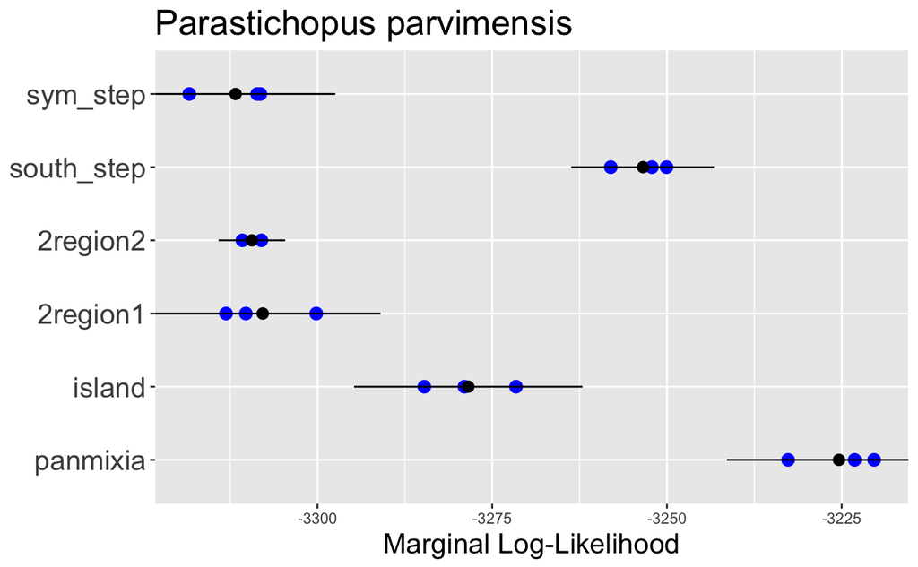